# Human Development Index (HDI) Analysis

## Data Prepartion for Research Question 2 and 3

The data defined here will be used in research question 2 and 3:

```r
dat_path <- "data/data.xlsx"

# Table 1 - HDI and its Components
hdi_and_components <- read_excel(dat_path, sheet = "Table 1")[-c(75,129,167), c(1,2,3,5,7,9,11)][8:196,]
colnames(hdi_and_components) <- c("Rank", "Country", "HDI", "LifeExp", "ExpSchlYrs","MeaSchlYrs","GNIpcap")
hdi_and_components %>%
  mutate(Rank = as.numeric(Rank)) %>%
  mutate(HDI = as.numeric(HDI)) %>%
  mutate(LifeExp = as.numeric(LifeExp)) %>%
  mutate(ExpSchlYrs = as.numeric(ExpSchlYrs)) %>%
  mutate(MeaSchlYrs = as.numeric(MeaSchlYrs)) %>%
  mutate(GNIpcap = as.numeric(GNIpcap)) %>%
  mutate(GNIpcap = GNIpcap / 1000) %>%
  mutate_if(is.numeric, round, digits=2) -> hdi_and_components

# Table 11 - Work and Employments
employment_status <- read_excel(dat_path, sheet = "Table 11")[-c(75,129,167), c(1,2,3,5,7,9,11,13,15)][9:197,]
colnames(employment_status) <- c("Rank", "Country", "EmpRatio", "LbrFPr", "EmpAgri","EmpServ","UEmpTotal","UEmpYouth","UEmpYNSchl")
employment_status %>%
  mutate(Rank = as.numeric(Rank)) %>%
  mutate(EmpRatio = as.numeric(EmpRatio)) %>%
  mutate(EmpAgri = as.numeric(EmpAgri)) %>%
  mutate(EmpServ = as.numeric(EmpServ)) %>%
  mutate(LbrFPr = as.numeric(LbrFPr)) %>%
  mutate(UEmpTotal = as.numeric(UEmpTotal)) %>%
  mutate(UEmpYouth = as.numeric(UEmpYouth)) %>%
  mutate(UEmpYNSchl = as.numeric(UEmpYNSchl)) %>%
  mutate_if(is.numeric, round, digits=2) -> employment_status
```

## Research Question 2

> **Among all the HDI components, which category has the most strong reflection with the HDI?**

To find the category with the most strong reflection with the HDI index, we are looking for a linear relationship between them with the distribution of data as tight as possible. In this case, all of the categories have a liner model there with HDI:

```r
hdi_and_components %>%
  select(HDI,LifeExp) %>%
  drop_na %>%
  ggplot(aes(HDI, LifeExp)) +
  geom_point() +
  geom_smooth(method = "lm") +
  xlab ("HDI Index") +
  ylab("Life Expectancy at Birth (Years)") +
  ggtitle("HDI and Life Expectancy at Birth") +
  theme_minimal() +
  geom_blank() -> plot_LifeExp

hdi_and_components %>%
  select(HDI,ExpSchlYrs) %>%
  drop_na %>%
  ggplot(aes(HDI, ExpSchlYrs)) +
  geom_point() +
  geom_smooth(method = "lm") +
  xlab ("HDI Index") +
  ylab("Expected School Years (Years)") +
  ggtitle("HDI and Expected School Years") +
  theme_minimal() +
  geom_blank() -> plot_ExpSchlYrs

hdi_and_components %>%
  select(HDI,GNIpcap) %>%
  drop_na %>%
  ggplot(aes(HDI, GNIpcap)) +
  geom_point() +
  geom_smooth(method = "lm") +
  xlab ("HDI Index") +
  ylab("Gross national income per capita ($1k)") +
  ggtitle("HDI and GNI per capita") +
  theme_minimal() +
  geom_blank() -> plot_GNI

hdi_and_components %>%
  select(HDI,MeaSchlYrs) %>%
  drop_na %>%
  ggplot(aes(HDI, MeaSchlYrs)) +
  geom_point() +
  geom_smooth(method = "lm") +
  xlab ("HDI Index") +
  ylab("Mean School Years (Years)") +
  ggtitle("HDI and School Years") +
  theme_minimal() +
  geom_blank() -> plot_MeaSchlYrs

hdi_and_components %>%
  select(Rank,LifeExp) %>%
  drop_na %>%
  ggplot(aes(Rank, LifeExp)) +
  geom_point() +
  geom_smooth(method = "lm") +
  xlab ("HDI Rank (Lower is Better)") +
  ylab("Life Expectancy at Birth (Years)") +
  ggtitle("HDI and Life Expectancy at Birth") +
  theme_minimal() +
  geom_blank() -> plot_LifeExp_rank

hdi_and_components %>%
  select(Rank,ExpSchlYrs) %>%
  drop_na %>%
  ggplot(aes(Rank, ExpSchlYrs)) +
  geom_point() +
  geom_smooth(method = "lm") +
  xlab ("HDI Rank (Lower is Better)") +
  ylab("Expected School Years (Years)") +
  ggtitle("HDI and Expected School Years") +
  theme_minimal() +
  geom_blank() -> plot_ExpSchlYrs_rank

hdi_and_components %>%
  select(Rank,GNIpcap) %>%
  drop_na %>%
  ggplot(aes(Rank, GNIpcap)) +
  geom_point() +
  geom_smooth(method = "lm") +
  xlab ("HDI Rank (Lower is Better)") +
  ylab("Gross national income per capita ($1k)") +
  ggtitle("HDI and GNI per capita") +
  theme_minimal() +
  geom_blank() -> plot_GNI_rank

hdi_and_components %>%
  select(Rank,MeaSchlYrs) %>%
  drop_na %>%
  ggplot(aes(Rank, MeaSchlYrs)) +
  geom_point() +
  geom_smooth(method = "lm") +
  xlab ("HDI Rank (Lower is Better)") +
  ylab("Mean School Years (Years)") +
  ggtitle("HDI and School Years") +
  theme_minimal() +
  geom_blank() -> plot_MeaSchlYrs_rank

plot_index <- ggarrange(plot_LifeExp, plot_ExpSchlYrs, plot_MeaSchlYrs, plot_GNI, nrow = 2, ncol = 2)
plot_rank <- ggarrange(plot_LifeExp_rank, plot_ExpSchlYrs_rank, plot_MeaSchlYrs_rank, plot_GNI_rank, nrow = 2, ncol = 2)
```

Now we can peak the distribution and the linear model easily with the scatter plot of both the HDI index and the rank:

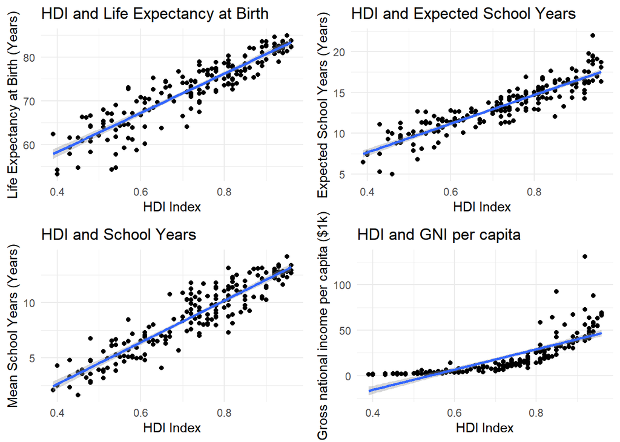

```r
plot_index
```

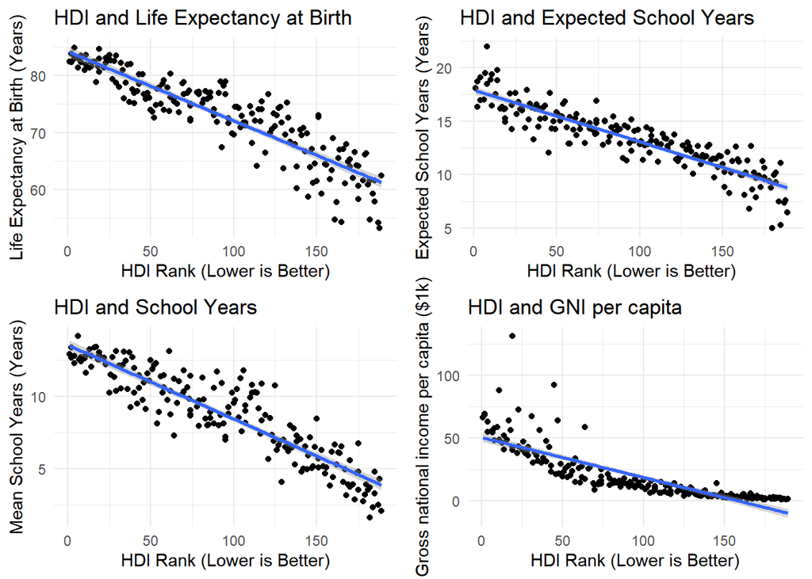

```r
plot_rank
```

```r
hdi_and_components %>%
  select(LifeExp, ExpSchlYrs, MeaSchlYrs, GNIpcap) %>%
  pivot_longer(everything()) %>%
  group_by(name) %>%
  summarise(sd = round(sd(value,na.rm = TRUE),digits = 2))
```

| name | sd |
| --- | --- |
| ExpSchlYrs | 2.94 |
| GNIpcap | 21.34 |
| LifeExp | 7.42 |
| MeaSchlYrs | 3.09 |

Thus, Expected School Years has the most strong relationship with the HDI.

## Research Question 3

> **How does the employment status of each country related to their HDI rank?**

In order to analyse how the employment situation of each country can relate to their HDI rank, we can use the `plot()` function to glimpse an overview:

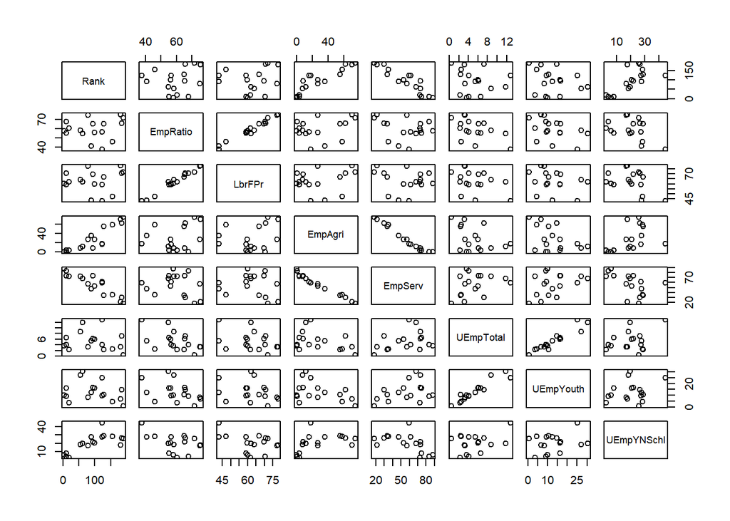

```r
employment_status %>%
  keep(is.numeric) %>%
  sample_frac(0.1) %>%
  plot()
```

It seems like there are interesting behaviors happening on `EmpAgri` and `EmpServ`, Let’s zoom in:

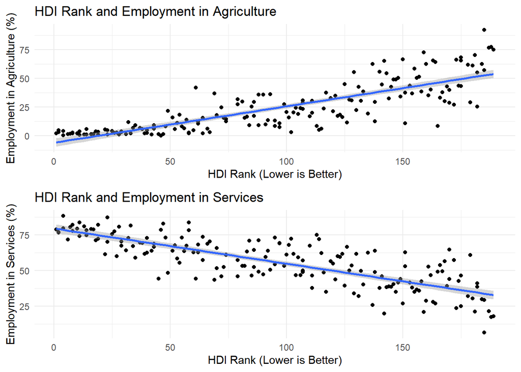

```r
employment_status %>%
  select(Rank,EmpAgri) %>%
  drop_na %>%
  ggplot(aes(Rank, EmpAgri)) +
  geom_point() +
  geom_smooth(method = "lm") +
  xlab ("HDI Rank (Lower is Better)") +
  ylab("Employment in Agriculture (%)") +
  ggtitle("HDI Rank and Employment in Agriculture") +
  theme_minimal() +
  geom_blank() -> plot_EmpAgri

employment_status %>%
  select(Rank,EmpServ) %>%
  drop_na %>%
  ggplot(aes(Rank, EmpServ)) +
  geom_point() +
  geom_smooth(method = "lm") +
  xlab ("HDI Rank (Lower is Better)") +
  ylab("Employment in Services (%)") +
  ggtitle("HDI Rank and Employment in Services") +
  theme_minimal() +
  geom_blank() -> plot_EmpServ

ggarrange(plot_EmpAgri, plot_EmpServ, nrow = 2, ncol = 1)
```

It is quite clear and direct: The country ranked higher in the HDI will engage a obviously high rate of employment in services and low rate of employment in agriculture, stepping into the third industry is an essential key to a better development.

But how about the overall employment and unemployment, how would they affect the HDI?

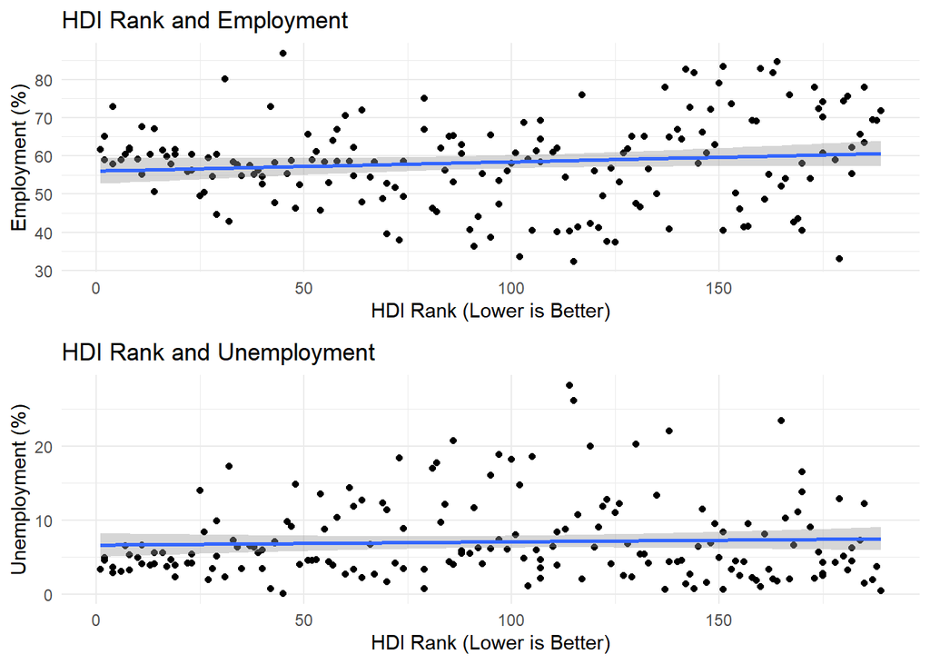

```r
employment_status %>%
  select(Rank,EmpRatio) %>%
  drop_na %>%
  ggplot(aes(Rank, EmpRatio)) +
  geom_point() +
  geom_smooth(method = "lm") +
  xlab ("HDI Rank (Lower is Better)") +
  ylab("Employment (%)") +
  ggtitle("HDI Rank and Employment") +
  theme_minimal() +
  geom_blank() -> plot_EmpRation

employment_status %>%
  select(Rank,UEmpTotal) %>%
  drop_na %>%
  ggplot(aes(Rank, UEmpTotal)) +
  geom_point() +
  geom_smooth(method = "lm") +
  xlab ("HDI Rank (Lower is Better)") +
  ylab("Unemployment (%)") +
  ggtitle("HDI Rank and Unemployment") +
  theme_minimal() +
  geom_blank() -> plot_EmpUEmpTotal

ggarrange(plot_EmpRation, plot_EmpUEmpTotal, nrow = 2, ncol = 1)
```

## Research Question 4

> **Is there a difference in ‘Workforce Participation Rate (WPR)’ between males and females in the four different HDI catgeories?**

The UN has cartgeorised the HDI value of countries into 4 broad classifications that provide an indication of the countries development as shown below:

- Very High Human Development = HDI Value > 0.898
- High Human Development = HDI Value > 0.753
- Medium Human Development = HDI Value > 0.631
- Low Development = HDI Value > 0.513

Through the use of a violin plot we were able to visualise the WPR (%) of males and females in relation the HDI value of the country, which brought to forefront clear trends.

There are clear seperations between the WPR of the genders and the HDI class of the country namely one being, female participation rate on average remains lower than male participation rates, despite the HDI category. This may be caused by remenants of societal values that did not encourage or rather presented barriers of entry for females into the workforce. Futhermore, it is often expected for females to also be primary caregivers which may reduce the tendancy for WFP across the board (The gender gap in employment: What’s holding women back?, 2021)

Very High HDI countries tend to have a WPR with a smaller distribution than that of Low HDI countries in both genders, and is clearly depicted as the size of the violins elongate as HDI value decreases. Higher HDI countries tend to be more bulbous indicating a certain level of uniformity within the living standards compared to the larger disparity in lower HDI countries.

In summary it is clearly evident that WPR have unique characteristics for each HDI category that are evident across genders. Futhermore the participation rate of genders do not tend to be a good indicator of the countries HDI value or category.

```r
LF_data <- read_csv("data/Labour Force Data.csv")
```

```
## * `` -> ...7
## * `` -> ...8
```

```r
head(LF_data)
```

| Country | Female Labour Force Participation Rate | Male Labour Force Particiaption Rate | HDI Rank | HDI Value | HDI Category | ...7 | ...8 |
| --- | --- | --- | --- | --- | --- | --- | --- |
| Norway | 60.4 | 67.2 | 1 | 0.957 | Very High HDI | NA | NA |
| Ireland | 56.0 | 68.4 | 2 | 0.955 | Very High HDI | NA | NA |
| Switzerland | 62.9 | 73.8 | 2 | 0.955 | Very High HDI | NA | NA |
| Hong Kong, China (SAR) | 54.0 | 67.5 | 4 | 0.949 | Very High HDI | NA | NA |
| Iceland | 70.8 | 79.2 | 4 | 0.949 | Very High HDI | NA | NA |
| Germany | 55.3 | 66.6 | 6 | 0.947 | Very High HDI | NA | NA |

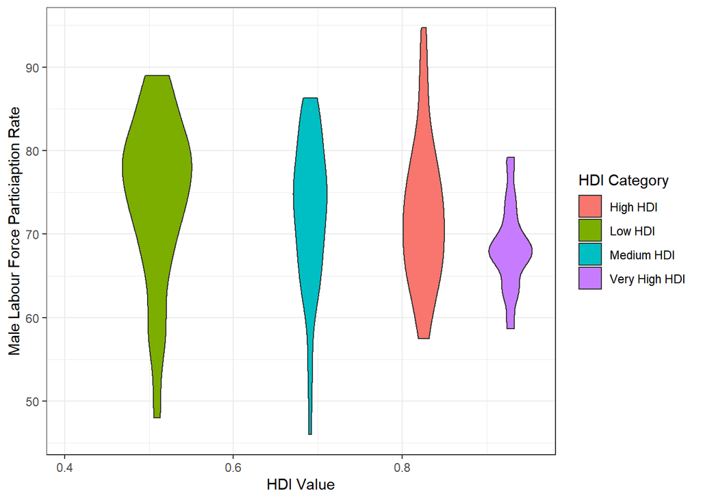

```r
mv <- LF_data %>%
  ggplot( aes(`HDI Value`, `Male Labour Force Particiaption Rate`, fill= `HDI Category`)) +
  geom_violin() +
  theme_bw()

mv
```

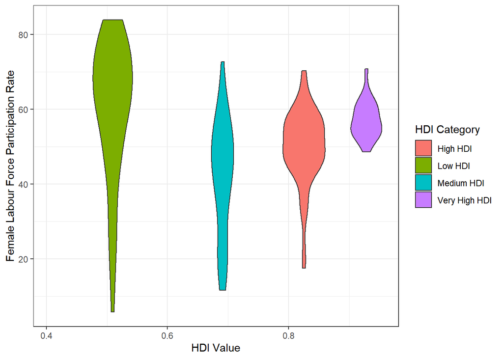

```r
fv <- LF_data %>%
  ggplot( aes(`HDI Value`, `Female Labour Force Participation Rate`, fill= `HDI Category`)) +
  geom_violin() +
  theme_bw()

fv
```

# References

- Al-Hilani, H., 2012. HDI as a measure of human development: A better index than the income approach. Journal of Business and Management, vol. 2, no. 5, pp.24-28.
- Ilo.org. 2021. The gender gap in employment: What’s holding women back?. [online] Available at: https://www.ilo.org/infostories/en-GB/Stories/Employment/barriers-women#pressure [Accessed 5 September 2021].